# Coursera JHU Getting and Cleaning Data Course Project

## tGravityAcc-std()-X

| Feature | Result |
| --- | --- |
| Variable type | numeric |
| Number of missing obs. | 0 (0 %) |
| Number of unique values | 10288 |
| Median | -0.98 |
| 1st and 3rd quartiles | -0.99; -0.96 |
| Min. and max. | -1; 1 |

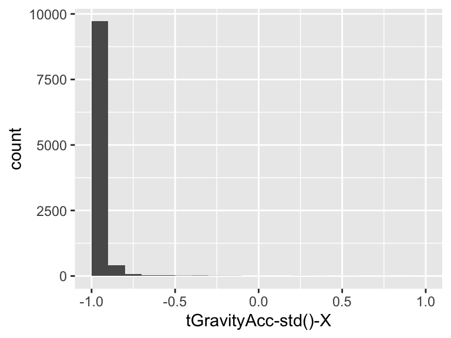

- Note that the following possible outlier values were detected: "-0.82690768", "-0.82687765", "-0.82643399", "-0.82608142", "-0.82603058", "-0.8257433", "-0.82484849", "-0.82460252", "-0.82413975", "-0.82395836" (216 additional values omitted).

## tGravityAcc-std()-Y

| Feature | Result |
| --- | --- |
| Variable type | numeric |
| Number of missing obs. | 0 (0 %) |
| Number of unique values | 10293 |
| Median | -0.98 |
| 1st and 3rd quartiles | -0.99; -0.95 |
| Min. and max. | -1; 1 |

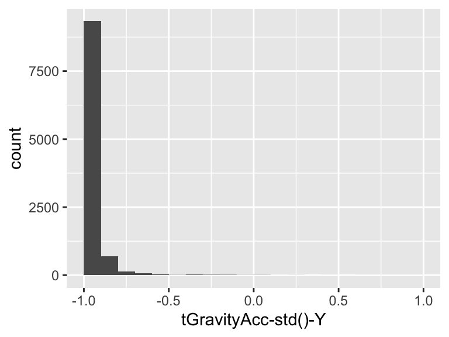

- Note that the following possible outlier values were detected: "-0.72474879", "-0.72466654", "-0.72444626", "-0.72302302", "-0.72068284", "-0.71982324", "-0.71975627", "-0.71864668", "-0.71859861", "-0.71747128" (158 additional values omitted).

## tGravityAcc-std()-Z

| Feature | Result |
| --- | --- |
| Variable type | numeric |
| Number of missing obs. | 0 (0 %) |
| Number of unique values | 10296 |
| Median | -0.97 |
| 1st and 3rd quartiles | -0.99; -0.93 |
| Min. and max. | -1; 1 |

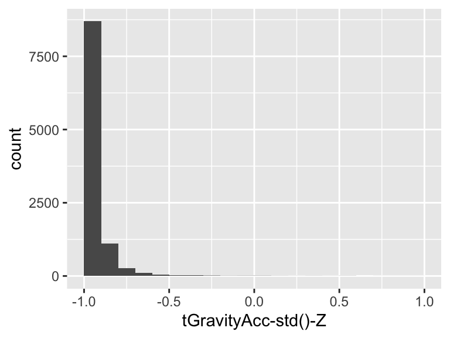

- Note that the following possible outlier values were detected: "-0.65821695", "-0.65751329", "-0.65733141", "-0.65685031", "-0.65552789", "-0.65530627", "-0.65313671", "-0.65313487", "-0.64932559", "-0.6483279" (173 additional values omitted).

## tGravityAccMag-mean()

| Feature | Result |
| --- | --- |
| Variable type | numeric |
| Number of missing obs. | 0 (0 %) |
| Number of unique values | 10296 |
| Median | -0.87 |
| 1st and 3rd quartiles | -0.98; -0.12 |
| Min. and max. | -1; 1 |

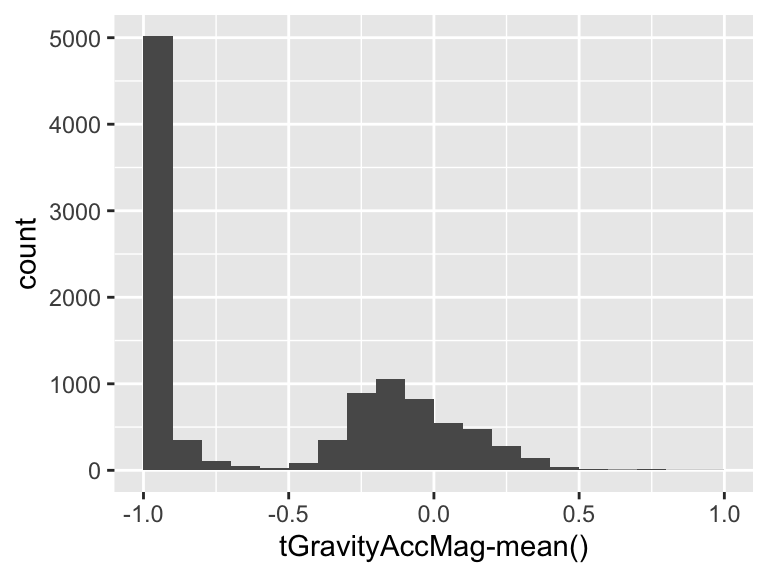

## tGravityAccMag-std()

| Feature | Result |
| --- | --- |
| Variable type | numeric |
| Number of missing obs. | 0 (0 %) |
| Number of unique values | 10294 |
| Median | -0.84 |
| 1st and 3rd quartiles | -0.98; -0.24 |
| Min. and max. | -1; 1 |

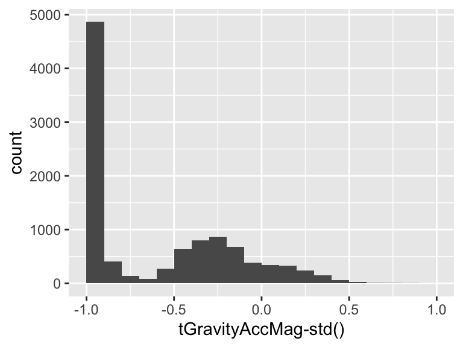

Report generation information:

- Created by: Sébastien (username: `sebastien`).
- Report creation time: Jeu fév 04 2021 04:14:53
- Report was run from directory: `/Users/sebastien/Documents/Coursera/3 - Getting-and-cleaning-data/Project Course`
- dataMaid v1.4.0 [Pkg: 2019-12-10 from CRAN (R 4.0.2)]
- R version 4.0.3 (2020-10-10).
- Platform: x86_64-apple-darwin17.0 (64-bit)(macOS Big Sur 10.16).
- Function call: `makeDataReport(data = HAR_set, output = "html", render = F, useVar = NULL, ordering = "alphabetical", smartNum = FALSE, standAlone = TRUE, maxDecimals = Inf, codebook = TRUE, reportTitle = "Coursera JHU Getting and Cleaning Data Course Project")`